# 201.13. ShearObject table

For the Rubin Science Platform at data.lsst.cloud.  
Data Release: [Data Preview 2](https://dp2.lsst.io/)  
Container Size: large  
LSST Science Pipelines version: r30.0.10  
Last verified to run: 2026-07-23  
Repository: github.com/lsst/tutorial-notebooks  
DOI: 10.11578/rubin/dc.20250909.20

**Learning objective:** To understand the contents of the `ShearObject` table and how to access it.

**LSST data products:** `ShearObject`

**Packages:** `lsst.rsp`, `lsst.daf.butler`

**Credit:** Originally developed by the Rubin Community Science team. Please consider acknowledging them if this notebook is used for the preparation of journal articles, software releases, or other notebooks.

**Get Support:** Everyone is encouraged to ask questions or raise issues in the [Support Category](https://community.lsst.org/c/support/6) of the Rubin Community Forum. Rubin staff will respond to all questions posted there.

## 1. Introduction

The `ShearObject` table contains measurements of objects detected and measured on coadded images with metadetection. The metadetection algorithm involves applying an artificial shear to images of small regions of sky and performing detection on the sheared images, as well as measurements that are used to calculate a shear response ([Sheldon et al. 2020](https://ui.adsabs.harvard.edu/abs/2020ApJ...902..138S/abstract), [Sheldon et al. 2023](https://ui.adsabs.harvard.edu/abs/2023OJAp....6E..17S/abstract), [Yamamoto et al. 2025](https://ui.adsabs.harvard.edu/abs/2025MNRAS.543.4156Y/abstract)).

- TAP table name: `dp2.ShearObject`
- butler table name: `object_shear_all`
- columns: 67

**Related tutorials:** The Table Access Protocol (TAP) and Butler data access services are demonstrated in the 100-level "How to" tutorials. There is a 200-level tutorial on `deep_coadd` images.

### 1.1. Import packages

Import standard python packages `re`, `numpy`, and `matplotlib`.

From the `lsst` package, import modules for the TAP service and the butler.

```python
import re
import numpy as np
import matplotlib.pyplot as plt
from lsst.rsp import RSPDiscovery
from lsst.daf.butler import Butler
```

### 1.2. Define parameters and functions

Create an instance of the TAP service, and assert that it exists.

```python
discovery = RSPDiscovery("dp2")
service = discovery.get_tap_client()
assert service is not None
```

Create an instance of the Rubin data Butler, and assert that it exists.

```python
butler = Butler("dp2", collections="dp2")
assert butler is not None
```

## 2. Schema (columns)

To browse the table schema visit the [Rubin schema browser](https://sdm-schemas.lsst.io/dp2.html#ShearObject), or use the TAP service via the Portal Aspect or as demonstrated in Section 2.1.

### 2.1. Retrieve table schema

To retrieve the table schema, define a query for the schema columns of the `ShearObject` table and run the query job.

```python
query = "SELECT column_name, datatype, description, unit " \
        "FROM tap_schema.columns " \
        "WHERE table_name = 'dp2.ShearObject'"
job = service.submit_job(query)
job.run()
job.wait(phases=['COMPLETED', 'ERROR'])
print('Job phase is', job.phase)
if job.phase == 'ERROR':
    job.raise_if_error()
```

```
Job phase is COMPLETED
```

Retrieve the query results and display them as an `astropy` table with the `to_table()` attribute.

```python
assert job.phase == 'COMPLETED'
results = job.fetch_result().to_table()
results
```

*Table length=67*

| column_name str64 | datatype str64 | description str512 | unit str64 |
| --- | --- | --- | --- |
| shearObjectId | long | Unique identifier for a ShearObject, specific to a single metacalibration counterfactual image. |  |
| tract | long | Skymap tract ID |  |
| patch | long | Skymap patch ID |  |
| cell_x | int | Column of the cell within the patch on which this measurement was made. |  |
| cell_y | int | Row of the cell within the patch on which this measurement was made. |  |
| metaStep | char | Type of artificial shear applied to image. One of 'ns', '1p', '1m', '2p', '2m'. |  |
| image_flags | int | Flags for the image on which this measurement was made. |  |
| x | float | Centroid (tract, x-axis) of the detected ShearObject. |  |
| y | float | Centroid (tract, y-axis) of the detected ShearObject. |  |
| ra | double | Detected Right Ascension of the ShearObject. | deg |
| dec | double | Detected Declination of the ShearObject. | deg |
| psfOriginal_flags | int | Flags for the original PSF measurement, ORed over the shear bands. |  |
| psfOriginal_g1 | float | Reduced-shear g1 of the original PSF from adaptive moments, averaged over the shear bands. |  |
| psfOriginal_g2 | float | Reduced-shear g2 of the original PSF from adaptive moments, averaged over the shear bands. |  |
| psfOriginal_T | float | Trace (<x^2> + <y^2>) measurement of the original PSF from adaptive moments, averaged over the shear bands. | arcsec**2 |
| bmask_flags | int | bmask flags for the ShearObject. |  |
| ormask_flags | int | ored mask flags for the ShearObject. |  |
| mfrac | float | Gaussian-weighted masked fraction for the ShearObject. |  |
| gauss_psfReconvolved_flags | int | Flags for reconvolved PSF (measured with gauss algorithm). |  |
| gauss_psfReconvolved_g1 | float | Reduced-shear g1 of the reconvolved PSF (measured with gauss algorithm). |  |
| gauss_psfReconvolved_g2 | float | Reduced-shear g2 of the reconvolved PSF (measured with gauss algorithm). |  |
| gauss_psfReconvolved_T | float | Trace (<x^2> + <y^2>) of the reconvolved PSF (measured with gauss algorithm). | arcsec**2 |
| ... | ... | ... | ... |
| i_gaussFlux_flags | int | Flags set for flux in i band measured with gauss algorithm. |  |
| i_gaussFlux | float | Flux in i band (measured with gauss algorithm). | nJy |
| i_gaussFluxErr | float | Flux uncertainty in i band (measured with gauss algorithm). | nJy |
| z_gaussFlux_flags | int | Flags set for flux in z band measured with gauss algorithm. |  |
| z_gaussFlux | float | Flux in z band (measured with gauss algorithm). | nJy |
| z_gaussFluxErr | float | Flux uncertainty in z band (measured with gauss algorithm). | nJy |
| g_pgaussFlux_flags | int | Flags set for flux in g band measured with pgauss algorithm. |  |
| g_pgaussFlux | float | Flux in g band (measured with pgauss algorithm). | nJy |
| g_pgaussFluxErr | float | Flux uncertainty in g band (measured with pgauss algorithm). | nJy |
| r_pgaussFlux_flags | int | Flags set for flux in r band measured with pgauss algorithm. |  |
| r_pgaussFlux | float | Flux in r band (measured with pgauss algorithm). | nJy |
| r_pgaussFluxErr | float | Flux uncertainty in r band (measured with pgauss algorithm). | nJy |
| i_pgaussFlux_flags | int | Flags set for flux in i band measured with pgauss algorithm. |  |
| i_pgaussFlux | float | Flux in i band (measured with pgauss algorithm). | nJy |
| i_pgaussFluxErr | float | Flux uncertainty in i band (measured with pgauss algorithm). | nJy |
| z_pgaussFlux_flags | int | Flags set for flux in z band measured with pgauss algorithm. |  |
| z_pgaussFlux | float | Flux in z band (measured with pgauss algorithm). | nJy |
| z_pgaussFluxErr | float | Flux uncertainty in z band (measured with pgauss algorithm). | nJy |
| is_cell_inner | boolean | Whether the object peak is within the inner cell boundary . |  |
| is_patch_inner | boolean | Whether the object is within the inner patch boundary. |  |
| is_tract_inner | boolean | Whether the object is within the inner tract boundary. |  |
| is_primary | boolean | Whether this object is to be selected after de-duplication. |  |

The table displayed above has been truncated.

Option to print every column name as a list.

```python
# for col in results['column_name']:
#     print(col)
```

Option to use the regular expressions package `re` to find all column names that hold the `gaussFlux` for the four filters.

```python
# for col in results['column_name']:
#     if re.fullmatch('[griz]_gaussFlux', col):
#         print(col)
```

Option to search column names that contain the string defined by the `temp` variable.

```python
# temp = 'flags'
# temp = 'gauss'
# temp = 'pgauss'
# temp = 'psf'
# for col in results['column_name']:
#     if re.search(temp, col):
#         print(col)
```

Delete the job, but not the `results`.

```python
del query
job.delete()
```

### 2.2. Key columns

Of the 67 columns of the `ShearObject` table, a subset will be the most commonly used. They are mostly dimensionless unless otherwise specified.

#### 2.2.1. ShearObject Id

The long integer that uniquely identifies each row of the `ShearObject` table.

- `shearObjectId`

#### 2.2.2. Tract and patch

The skymap tract, patch, and cell identifiers.

- `tract`
- `patch`
- `cell_x`
- `cell_y`

#### 2.2.3. Coordinates

The sky coordinates in decimal degrees.

- `ra`
- `dec`

#### 2.2.4. Metadetection step

The type of artificial shear applied to the image. One of 'ns' (no shear), '1p' (positive shear applied along the first direction), '1m' (negative shear applied along the first direction), '2p' (positive shear applied along the second direction), '2m' (negative shear applied along the second direction). The first direction is along the x-axis while the second is along the 45 degrees above the x-axis counterclockwise.

- `metaStep`

#### 2.2.5. Fluxes

The Gaussian flux and its uncertainty, in nJy, for each of the four filters.

- `[f]_gaussFlux`
- `[f]_gaussFluxErr`

Here `[f]` is one of `g`, `r`, `i`, or `z`.

#### 2.2.6. Shapes

Reduced-shear measurements from the Gaussian algorithm.

- `gauss_g1`
- `gauss_g2`

Gaussian size in arcsec^2 and signal-to-noise measurements.

- `gauss_T`
- `gauss_snr`

#### 2.2.7. Flags

Flags for the Gaussian measurements and the de-duplication selection.

- `gauss_flags`
- `gauss_shape_flags`
- `gauss_object_flags`
- `is_primary`

### 2.3. Descriptions and units

For a subset of the key columns show the table of their descriptions and units.

```python
col_list = set(['shearObjectId', 'tract', 'patch', 'metaStep',
                'ra', 'dec', 'gauss_g1', 'gauss_g2',
                'gauss_snr', 'gauss_T',
                'r_gaussFlux', 'r_gaussFluxErr',
                'is_primary'])
tx = [i for i, item in enumerate(results['column_name'])
      if item in col_list]
results[tx]
```

*Table length=13*

| column_name str64 | datatype str64 | description str512 | unit str64 |
| --- | --- | --- | --- |
| shearObjectId | long | Unique identifier for a ShearObject, specific to a single metacalibration counterfactual image. |  |
| tract | long | Skymap tract ID |  |
| patch | long | Skymap patch ID |  |
| metaStep | char | Type of artificial shear applied to image. One of 'ns', '1p', '1m', '2p', '2m'. |  |
| ra | double | Detected Right Ascension of the ShearObject. | deg |
| dec | double | Detected Declination of the ShearObject. | deg |
| gauss_g1 | float | Reduced-shear g1 measurement of the ShearObject (measured with gauss algorithm). |  |
| gauss_g2 | float | Reduced-shear g2 measurement of the ShearObject (measured with gauss algorithm). |  |
| gauss_snr | float | Signal-to-noise ratio measure of the ShearObject (measured with gauss algorithm). |  |
| gauss_T | float | Trace (<x^2> + <y^2>) measurement of the ShearObject (measured with gauss algorithm). | arcsec**2 |
| r_gaussFlux | float | Flux in r band (measured with gauss algorithm). | nJy |
| r_gaussFluxErr | float | Flux uncertainty in r band (measured with gauss algorithm). | nJy |
| is_primary | boolean | Whether this object is to be selected after de-duplication. |  |

Clean up.

```python
del col_list, tx, results
```

## 3. Data access

The `ShearObject` table is accessible via the TAP service and the Butler.

**Recommended access method:** TAP.

### 3.1. Advisory: avoid full-table queries

**Avoid full-table queries. Always include spatial constraints.**

The `ShearObject` table is a large, inclusive set of measurements made on coadded images for objects detected and measured during metadetection processing.

Although queries of small DP2 regions can run quickly, skipping spatial constraints is not a good habit to form because future data releases will contain much larger tables.

### 3.2. TAP (Table Access Protocol)

The `ShearObject` table is stored in [Qserv](https://qserv.lsst.io/user/index.html) and accessible via the TAP services using Astronomical Data Query Language (ADQL) queries.

**Include spatial constraints:** Qserv stores catalog data sharded by coordinate (RA, Dec), so ADQL queries that include coordinate constraints do not require a whole-catalog search and are typically faster than queries that constrain only other columns.

Use an ADQL cone or polygon search for faster queries. Do not use `WHERE ... BETWEEN` statements to set boundaries on RA and Dec.

#### 3.2.1. Demo query

Define a query to return the "key columns" from Section 2.2.

Impose **spatial constraints**: search within a 0.05 degree radius of the center of the Extended Chandra Deep Field South (ECDFS) field, RA, Dec = $53.13, -28.10$.

Return primary rows for which `metaStep` is `ns`.

```python
query = "SELECT shearObjectId, tract, patch, metaStep, ra, dec, " \
        "gauss_g1, gauss_g2, gauss_snr, gauss_T, " \
        "r_gaussFlux, r_gaussFluxErr, is_primary " \
        "FROM dp2.ShearObject " \
        "WHERE CONTAINS(POINT('ICRS', ra, dec), " \
        "CIRCLE('ICRS', 53.13, -28.10, 0.05)) = 1 " \
        "AND metaStep = 'ns' " \
        "AND is_primary = 1"
job = service.submit_job(query)
job.run()
job.wait(phases=['COMPLETED', 'ERROR'])
print('Job phase is', job.phase)
if job.phase == 'ERROR':
    job.raise_if_error()
```

```
Job phase is COMPLETED
```

Fetch the results as an `astropy` table.

```python
assert job.phase == 'COMPLETED'
results = job.fetch_result().to_table()
print(len(results))
```

```
1174
```

Option to display the table.

```python
# results
```

Constrain the results to objects with r-band Gaussian magnitudes between 20 and 25 mag in the AB system (flux between 360 and 36000 nJy approximately).

```python
tx = np.where((results['r_gaussFlux'] > 360.0)
              & (results['r_gaussFlux'] <= 36000.0)
              & (results['r_gaussFluxErr'] > 0))[0]
print(len(tx))
```

```
764
```

Plot the sky coordinates and the r-band Gaussian magnitude versus signal-to-noise ratio (SNR) for the subset of objects.

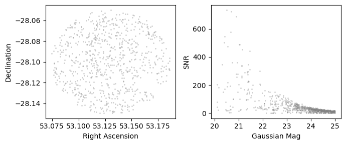

```python
fig, (ax1, ax2) = plt.subplots(1, 2, figsize=(7, 3))
ax1.plot(results['ra'][tx], results['dec'][tx],
         'o', ms=2, mew=0, alpha=0.4, color='grey')
ax1.set_xlabel('Right Ascension')
ax1.set_ylabel('Declination')
ax2.plot(-2.5 * np.log10(results['r_gaussFlux'][tx]) + 31.4,
         results['r_gaussFlux'][tx] / results['r_gaussFluxErr'][tx],
         'o', ms=2, mew=0, alpha=0.4, color='grey')
ax2.set_xlabel('Gaussian Mag')
ax2.set_ylabel('SNR')
plt.tight_layout()
plt.show()
```

> **Figure 1:** At left, the RA vs. Dec of retrieved shear objects is shown as a circle of grey points. At right, the r-band Gaussian magnitude vs. SNR shows how magnitude increases as SNR decreases.

Clean up.

```python
job.delete()
del results, tx
```

### 3.3. Butler

TAP is the recommended way to access the `ShearObject` table, but the Butler is a convenient way to retrieve all the shear objects in a given tract.

Show that the dimensions for the `object_shear_all` table are the skymap and tract, and that they are required.

```python
butler.get_dataset_type('object_shear_all')
```

```
DatasetType('object_shear_all', {skymap, tract}, ArrowAstropy)
```

```python
butler.get_dataset_type('object_shear_all').dimensions.required
```

```
{skymap, tract}
```

#### 3.3.1. Demo query

**Include spatial constraints:** The Butler `object_shear_all` table contents are stored and retrieved by individual tract.

Retrieve all `dataset_refs` for `object_shear_all` tables for tracts that overlap the coordinates near the center of the ECDFS field.

```python
query = "tract.region OVERLAPS POINT(53.13, -28.10)"
refs = butler.query_datasets("object_shear_all", where=query)
```

Show the tracts that overlap the coordinates.

```python
for ref in refs:
    print(ref.dataId)
```

```
{skymap: 'lsst_cells_v2', tract: 5063}
```

Define the columns to retrieve.

```python
col_list = ['shearObjectId', 'tract', 'patch', 'metaStep',
            'ra', 'dec', 'gauss_g1', 'gauss_g2',
            'gauss_snr', 'gauss_T',
            'r_gaussFlux', 'r_gaussFluxErr',
            'is_primary']
```

Get the data from the butler.

```python
results = butler.get(refs[0],
                     parameters={'columns': col_list})
```

Option to display the results.

```python
# results
```

Constrain the results to primary rows for which `metaStep` is `ns`, and with r-band Gaussian magnitudes between 20 and 25 mag.

```python
tx = np.where((results['metaStep'] == 'ns')
              & (results['is_primary'])
              & (results['r_gaussFlux'] > 360.0)
              & (results['r_gaussFlux'] <= 36000.0)
              & (results['r_gaussFluxErr'] > 0))[0]
print(len(tx))
```

```
244672
```

Plot the sky coordinates and Gaussian fluxes and flux errors for the subset of shear objects.

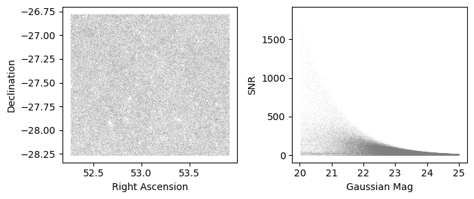

```python
fig, (ax1, ax2) = plt.subplots(1, 2, figsize=(7, 3))
ax1.plot(results['ra'][tx], results['dec'][tx],
         'o', ms=0.5, mew=0, alpha=0.1, color='grey')
ax1.set_xlabel('Right Ascension')
ax1.set_ylabel('Declination')
ax2.plot(-2.5 * np.log10(results['r_gaussFlux'][tx]) + 31.4,
         results['r_gaussFlux'][tx] / results['r_gaussFluxErr'][tx],
         'o', ms=0.5, mew=0, alpha=0.1, color='grey')
ax2.set_xlabel('Gaussian Mag')
ax2.set_ylabel('SNR')
plt.tight_layout()
plt.show()
```

> **Figure 2:** At left, the RA vs. Dec of retrieved shear objects is shown as grey points. At right, the r-band Gaussian magnitude vs. SNR shows how magnitude increases as SNR decreases.

```python
del query, refs, col_list, results, tx
```